# Programing functions and plotting with ggplot

Eric R. Scott

```r
library(ggplot2)
data(trees)
bees <- readRDS("BeeNectar.rds")
```

# BONUS MATERIAL!

In class, I asked if you wanted to see more about making functions and programming in R or more about making ggplot graphics.

# Making functions in R: SE_r

You will not be responsible for knowing how to calculate the standard error of r, but because there is no built-in function for calculating it in R, I’m going to use it as an example for how you might go about creating a function in R for those of you interested in programming in R.

The formula for the standard error of r is:

$$SE_r = \sqrt{\frac{1-r^2}{df}}$$

We can extract r and degrees of freedom from the results of `cor.test()` and use them to calculate SE_r

```r
trees.cortest <- cor.test(trees$Girth, trees$Height) #save results of cor.test()
#extract Pearsons r and df
r <- trees.cortest$estimate #r
df <- trees.cortest$parameter #df
#calculate SE of r
SE = sqrt((1-(r^2))/df)
# SE # since "r" was a named vector, the name carries through.  We might want to remove it, as it will be confusing
names(SE) <- NULL
SE
```

```
[1] 0.158696
```

Now, if we want to create a function to calculate SE_r on any correlation test result, we can start by selecting the code we just wrote and choosing “Extract Function” in the “Code” menu of R Studio. Give the function a name when it prompts you.

This is what the code looks like after doing “Extract Function” on it:

```r
SE_r <- function(trees.cortest) {
  #extract Pearsons r and df
  r <- trees.cortest$estimate #r
  df <- trees.cortest$parameter #df

  #calculate SE of r
  SE = sqrt((1-(r^2))/df)
  # SE # since "r" was a named vector, the name carries through.  We might want to remove it, as it will be confusing
  names(SE) <- NULL
  SE
}
#NOTE: you might want to change "trees.cortest" to something more generic, but that's optional
```

Now if you run this code, you should see the function `SE_r` added to your Environment window. Let’s try applying it to another dataset.

```r
bees.cortest <- cor.test(bees$Pollen, bees$ITS) #correlation between pollen return and bee size
SE_r(bees.cortest)
```

```
[1] 0.04366406
```

For more about writing functions in R, check out http://r4ds.had.co.nz/functions.html

# More complicated ggplots

So far we’ve only dealt with mapping data to x and y aesthetics, but you can map data to other aesthetics like color, shape, size, alpha (transparency).

Let’s look for any patterns in the relationship between ITS and Nectar between different colonies by mapping colony ID to the point color.

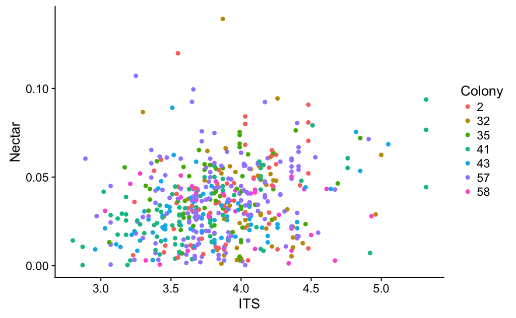

```r
ggplot(bees) +
  geom_point(aes(x = ITS, y = Nectar, color = Colony)) #x-axis = ITS, y-axis = Nectar, color = Colony ID
```

You could also change the color of all points by putting the `color =` argument *outside* of the `aes()`

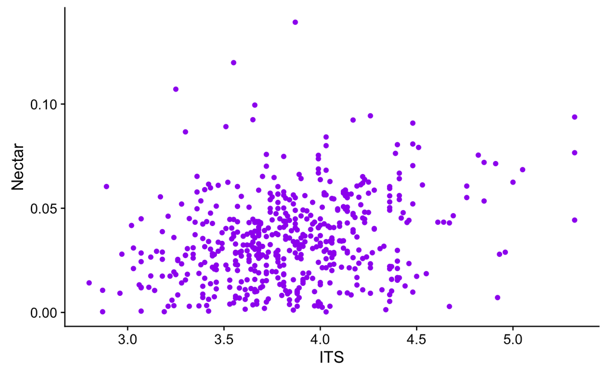

```r
ggplot(bees) +
  geom_point(aes(x = ITS, y = Nectar), color = "purple") #x-axis = ITS, y-axis = Nectar, color = Colony ID
```

If you map a continous variable to color, something slightly different happens

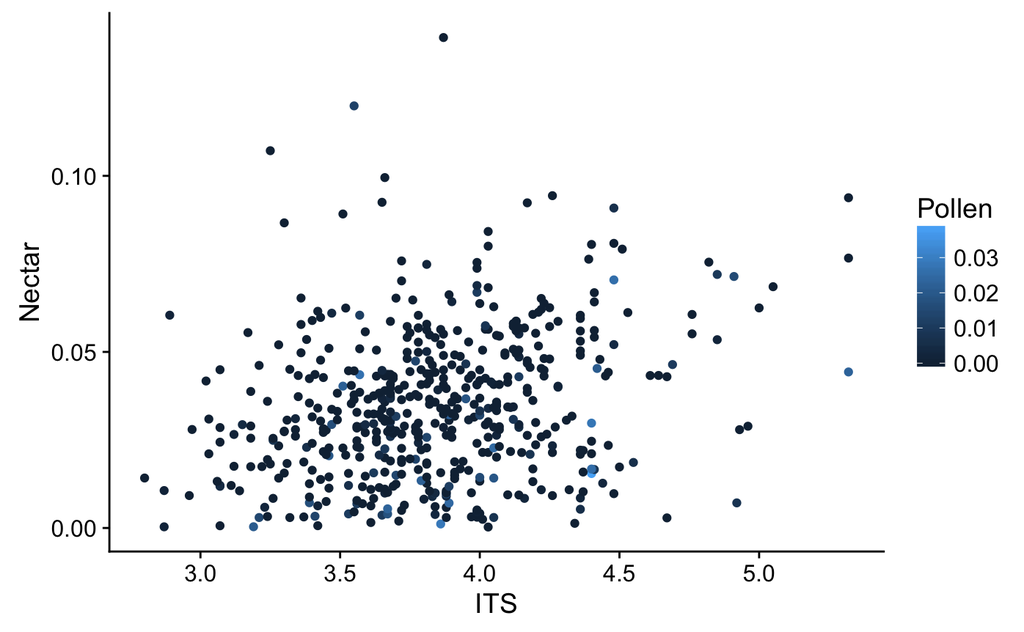

```r
ggplot(bees) +
  geom_point(aes(x = ITS, y = Nectar, color = Pollen)) #x-axis = ITS, y-axis = Nectar, color = Colony ID
```

Mapping ITS to point size makes sense and might reveal an interesting pattern. Bigger points = bigger bees. In this example I also change `alpha =` for all points to make them transparent and make overplotting more obvious.

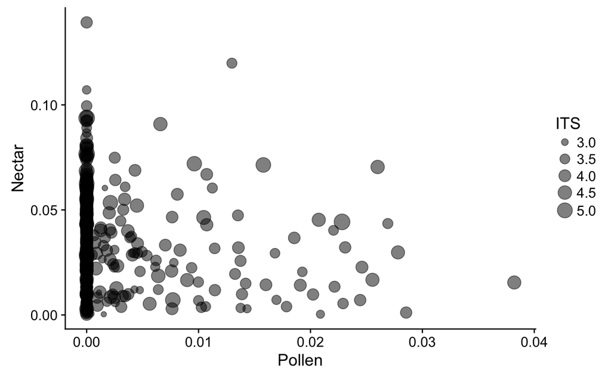

```r
ggplot(bees) +
  geom_point(aes(x = Pollen, y = Nectar, size = ITS), alpha = 0.5)
```

You can also change the shape or map shape to an aesthetic

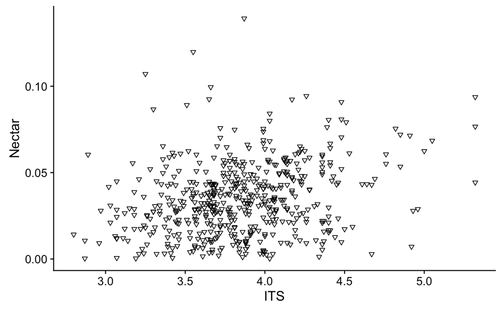

```r
#change shape for all points
ggplot(bees) +
  geom_point(aes(x = ITS, y = Nectar), shape = 25) #outside of aes() you can give shape =  a number to change the shape.  There are 25 shapes available in R.
```

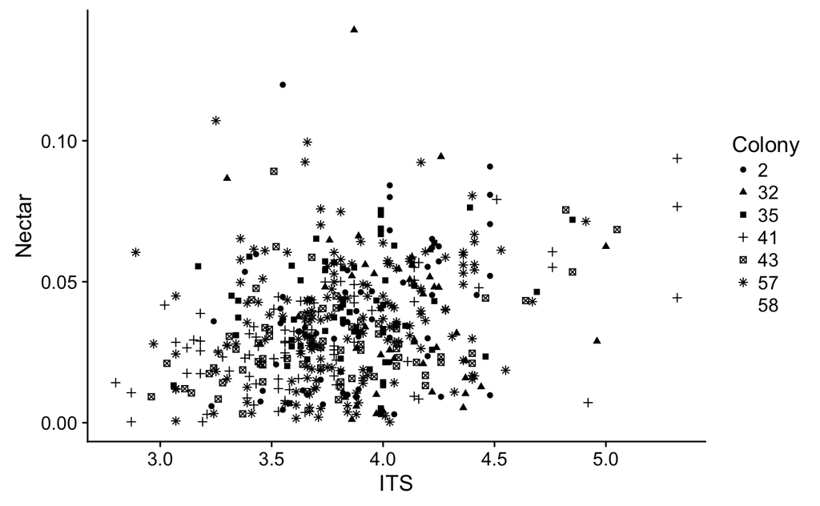

```r
#map shape to an aesthetic
ggplot(bees) +
  geom_point(aes(x = ITS, y = Nectar, shape = Colony))
```

Making things like color, fill, size, shape, or alpha into aesthetics that map to a variable works for all types of plots. Here’s a boxplot example:

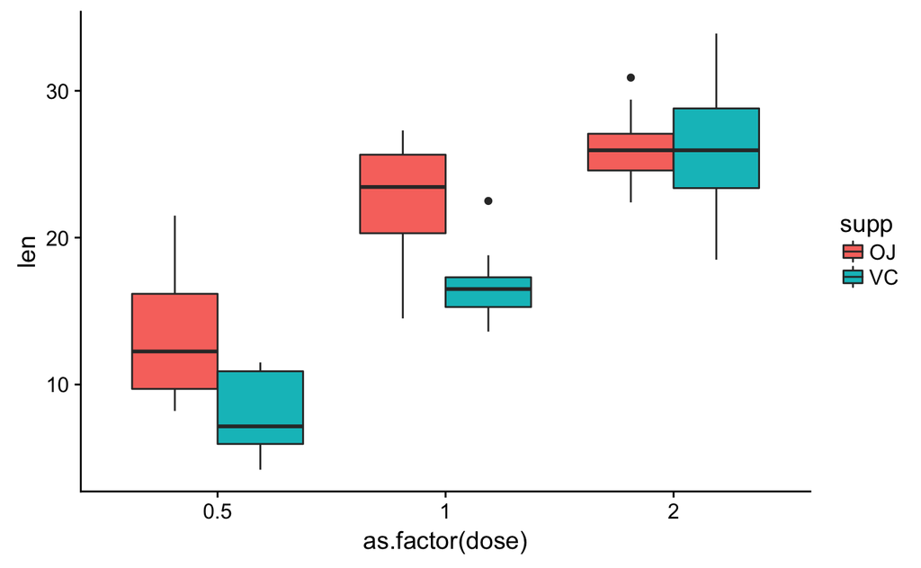

```r
data("ToothGrowth")
ggplot(ToothGrowth) +
  geom_boxplot(aes(x = as.factor(dose), y = len, fill = supp)) #"fill" is the inside of the boxplot box, the inside of some shapes, and the inside of bars in barplots.  In these cases "color" is the outline.
```

Using multiple aesthetics can be a powerful tool for data exploration!

For more on ggplot2 check out the folowing links:

- http://r4ds.had.co.nz/data-visualisation.html
- http://ggplot2.tidyverse.org/reference/index.html
- http://www.cookbook-r.com/Graphs/